# Intro to R: Loops, Conditionals, Functions

Richard Paquin Morel

September 2023

## Remember our data from Monday…

```r
gapminder <- read.csv(here::here("data", "gapminder5.csv"))
head(gapminder)
```

```
##       country year      pop continent lifeExp gdpPercap
## 1 Afghanistan 1952  8425333      Asia  28.801  779.4453
## 2 Afghanistan 1957  9240934      Asia  30.332  820.8530
## 3 Afghanistan 1962 10267083      Asia  31.997  853.1007
## 4 Afghanistan 1967 11537966      Asia  34.020  836.1971
## 5 Afghanistan 1972 13079460      Asia  36.088  739.9811
## 6 Afghanistan 1977 14880372      Asia  38.438  786.1134
```

## Sidebar: the `here` package

The `here()` function gets your current working directory and appends any strings enclosed in the function.

```r
# install.packages("here")
here::here()
```

```
## [1] "/Users/alice/bootcamp-2023"
```

```r
here::here("data", "gapminder.csv")
```

```
## [1] "/Users/alice/bootcamp-2023/data/gapminder.csv"
```

## Remember our data from Monday…

```r
gapminder <- read.csv(here::here("data", "gapminder5.csv"))
head(gapminder)
```

```
##       country year      pop continent lifeExp gdpPercap
## 1 Afghanistan 1952  8425333      Asia  28.801  779.4453
## 2 Afghanistan 1957  9240934      Asia  30.332  820.8530
## 3 Afghanistan 1962 10267083      Asia  31.997  853.1007
## 4 Afghanistan 1967 11537966      Asia  34.020  836.1971
## 5 Afghanistan 1972 13079460      Asia  36.088  739.9811
## 6 Afghanistan 1977 14880372      Asia  38.438  786.1134
```

## `gapminder` dataset

```r
str(gapminder)
```

```
## 'data.frame':    1704 obs. of  6 variables:
##  $ country  : chr  "Afghanistan" "Afghanistan" "Afghanistan" "Afghanistan" ...
##  $ year     : int  1952 1957 1962 1967 1972 1977 1982 1987 1992 1997 ...
##  $ pop      : num  8425333 9240934 10267083 11537966 13079460 ...
##  $ continent: chr  "Asia" "Asia" "Asia" "Asia" ...
##  $ lifeExp  : num  28.8 30.3 32 34 36.1 ...
##  $ gdpPercap: num  779 821 853 836 740 ...
```

## `gapminder` dataset

```r
gapminder$country <- as.character(gapminder$country)
gapminder$continent <- as.character(gapminder$continent)
str(gapminder)
```

```
## 'data.frame':    1704 obs. of  6 variables:
##  $ country  : chr  "Afghanistan" "Afghanistan" "Afghanistan" "Afghanistan" ...
##  $ year     : int  1952 1957 1962 1967 1972 1977 1982 1987 1992 1997 ...
##  $ pop      : num  8425333 9240934 10267083 11537966 13079460 ...
##  $ continent: chr  "Asia" "Asia" "Asia" "Asia" ...
##  $ lifeExp  : num  28.8 30.3 32 34 36.1 ...
##  $ gdpPercap: num  779 821 853 836 740 ...
```

## `gapminder` dataset

- What if we want to know the mean life expectancy by country? -Or by year?
- One approach:

```r
mean(gapminder$lifeExp[gapminder$country == "Afghanistan"])
```

```
## [1] 37.47883
```

```r
mean(gapminder$lifeExp[gapminder$country == "Albania"])
```

```
## [1] 68.43292
```

```r
#...
```

## `gapminder` dataset

- Or we could do save ourselves a lot of typing and time
- Loops!

# Don’t repeat yourself–loop it!

## Loops in R – `for`, `while`, and the `apply` family

- Loops allow you to repeat a function based on conditions
- There are several flavors
  - `for`
  - `while`
  - the `apply` family (often preferred to loops because the code is cleaner)
- Sneak peak: `dplyr` and `data.table` offer better approaches to loops

## A word of caution about loops

- It is often a good idea at avoid loops when possible in R
  - They are slow!
- Try to find other solutions before looping

## The anatomy of a `for` loop

- `for` loops repeat a function for all values in a vector – *don’t cut and paste!*
- The basic form is: `for (i in vector) { function(i) }`
  - `i` is the iterator variable (could be any letter!)
  - The loop repeats for each value in the vector, which replaces `i` for each interation

## The anatomy of a `for` loop

- Let’s recover the GDP for each country

```r
# create a vector of values that you want to repeat the function for
obs <- 1:nrow(gapminder)

# initialize the for loop with `for (i in vector)`
for (i in obs) { # the function to repeat is enclosed in braces {}
  gapminder[i, "gdp"] <- gapminder[i, "pop"] * gapminder[i, "gdpPercap"]
}
```

## You try

Create a new variable that finds that natural log (`log`) of the GDP per capita and of population - call them `log_gdpPercap` and `log_pop`

## Log gdp and log population

```r
# initialize the for loop with `for (i in vector)`
for (i in obs) { # the function to repeat is enclosed in braces {}
  gapminder[i, "log_gdpPercap"] <- log(gapminder[i, "gdpPercap"])
  gapminder[i, "log_pop"] <- log(gapminder[i, "pop"])
}
```

## Log gdp and log population

```r
head(gapminder)
```

```
##       country year      pop continent lifeExp gdpPercap         gdp
## 1 Afghanistan 1952  8425333      Asia  28.801  779.4453  6567086330
## 2 Afghanistan 1957  9240934      Asia  30.332  820.8530  7585448670
## 3 Afghanistan 1962 10267083      Asia  31.997  853.1007  8758855797
## 4 Afghanistan 1967 11537966      Asia  34.020  836.1971  9648014150
## 5 Afghanistan 1972 13079460      Asia  36.088  739.9811  9678553274
## 6 Afghanistan 1977 14880372      Asia  38.438  786.1134 11697659231
##   log_gdpPercap  log_pop
## 1      6.658583 15.94675
## 2      6.710344 16.03915
## 3      6.748878 16.14445
## 4      6.728864 16.26115
## 5      6.606625 16.38655
## 6      6.667101 16.51555
```

## Avoid loops when possible

- Loops are useful, but slow
- Avoid when possible, especially when there is a vectorized function you can use

```r
gapminder$vec_log_gdpPercap <- log(gapminder$gdpPercap)
all(gapminder$vec_log_gdpPercap == gapminder$log_gdpPercap)
```

```
## [1] TRUE
```

## Let’s try something a bit more substantive

- Has life expectancy increased over time?
- Find the mean life expectancy by year

```r
years <- unique(gapminder$year)

for (i in years) {
  mean_le <- mean(gapminder$lifeExp[gapminder$year == i],
                  na.rm = T)
  print(paste0(i, ": ", mean_le))
}
```

```
## [1] "1952: 49.0576197183099"
## [1] "1957: 51.5074011267606"
## [1] "1962: 53.6092490140845"
## [1] "1967: 55.6782895774648"
## [1] "1972: 57.6473864788732"
## [1] "1977: 59.5701574647887"
## [1] "1982: 61.5331971830986"
## [1] "1987: 63.2126126760563"
## [1] "1992: 64.160338028169"
## [1] "1997: 65.014676056338"
## [1] "2002: 65.6949225352113"
## [1] "2007: 67.0074225352113"
```

## Mean life expectancy by continent

- Try the same, this time for continents!
  - Which continent has the highest mean life expectancy?

## Mean life expectancy by continent

```r
conts <- unique(gapminder$continent)

for (i in conts) {
  mean_le <- mean(gapminder$lifeExp[gapminder$continent == i],
                  na.rm = T)
  print(paste0(i, ": ", mean_le))
}
```

```
## [1] "Asia: 60.0649032323232"
## [1] "Europe: 71.9036861111111"
## [1] "Africa: 48.8653301282051"
## [1] "Americas: 64.6587366666667"
## [1] "Oceania: 74.3262083333333"
```

## double up!

- It is possible to make nested `for` loops by defining different iterators
- What is the mean life expectancy for each continent for each year?

## the nested `for` loop

```r
for (i in conts) {
  print(paste0("Continent: ", i))
  for (j in years) {
    mean_le <- mean(gapminder$lifeExp[gapminder$continent == i &
                                          gapminder$year == j],
                      na.rm = T)
    print(paste0(j, ": ", mean_le))
  }
  }
```

```
## [1] "Continent: Asia"
## [1] "1952: 46.3143939393939"
## [1] "1957: 49.3185442424242"
## [1] "1962: 51.563223030303"
## [1] "1967: 54.66364"
## [1] "1972: 57.3192690909091"
## [1] "1977: 59.6105563636364"
## [1] "1982: 62.6179393939394"
## [1] "1987: 64.8511818181818"
## [1] "1992: 66.5372121212121"
## [1] "1997: 68.0205151515152"
## [1] "2002: 69.2338787878788"
## [1] "2007: 70.7284848484849"
## [1] "Continent: Europe"
## [1] "1952: 64.4085"
```

[output cut: 50 more lines]

## nested `for` loop exercise!

- Has the gap in life expectancy between countries on different continents narrowed over time?

## nested `for` loop exercise!

- What is the standard deviation (`sd`) for life expectancy for each continent for each year?

## nested `for` loop exercise!

```r
for (i in conts) {
  print(paste0("Continent: ", i))
  for (j in years) {
    sd_le <- sd(gapminder$lifeExp[gapminder$continent == i &
                                          gapminder$year == j],
                    na.rm = T)
    print(paste0(j, ": ", sd_le))
  }
}
```

```
## [1] "Continent: Asia"
## [1] "1952: 9.29175069597824"
## [1] "1957: 9.63542861940215"
## [1] "1962: 9.82063194066467"
## [1] "1967: 9.65096458232544"
## [1] "1972: 9.72270004073083"
## [1] "1977: 10.0221969818167"
## [1] "1982: 8.53522140873991"
## [1] "1987: 8.20379188414779"
## [1] "1992: 8.07554897033932"
## [1] "1997: 8.09117060876087"
## [1] "2002: 8.37459538857541"
## [1] "2007: 7.96372447069057"
## [1] "Continent: Europe"
## [1] "1952: 6.36108825405387"
```

[output cut: 50 more lines]

# `for` loops can be slow…very slow

## `for` loops can be slow…very slow

- Sometimes, people recommend using the `apply` family of functions as a faster alternative
  - There are *some* efficiency gains with smaller datasets
  - But, as Patrick Burns, the author of “R Inferno”, states, the `apply` family is “loop-hiding”
- `apply` and its relatives help you write cleaner code, but do not expect much of a speed boost
  - do a search for “for loops versus apply in r” and get a taste for the debate

## Three flavors: `apply`, `lapply`, `sapply`

- Let’s look at these three (there are more!): `apply`, `lapply`, `sapply`

## `apply`

`apply(matrix, 1 = row or 2 = column, function)` - Let’s say we want to find the mean for each stat in `gapminder`

```r
vars <- gapminder[, c("lifeExp", "pop", "gdpPercap")]
apply(vars, 2, mean)
```

```
##      lifeExp          pop    gdpPercap
## 5.947444e+01 2.960121e+07 7.215327e+03
```

## `apply` versus `for`

```r
apply(vars, 2, mean)
```

```
##      lifeExp          pop    gdpPercap
## 5.947444e+01 2.960121e+07 7.215327e+03
```

```r
for (i in vars) {
  print(mean(i))
}
```

```
## [1] 59.47444
## [1] 29601212
## [1] 7215.327
```

## `lapply` and `sapply`

- Both `lapply` and `sapply` iterate over a values in a vector or list, rather than rows or columns
  - Generally, much more common to use in data analysis
- `lapply` returns a list
- `sapply` returns a simplified list (i.e., a vector)
  - Word of caution – there is some inconsistency in how `sapply` returns results, so always check

## `lapply` and `sapply`

- `lapply(vector, function)`

```r
lapply(gapminder, mean)
```

```
## $country
## [1] NA
##
## $year
## [1] 1979.5
##
## $pop
## [1] 29601212
##
## $continent
## [1] NA
##
## $lifeExp
## [1] 59.47444
##
## $gdpPercap
## [1] 7215.327
##
## $gdp
## [1] 186809560507
##
## $log_gdpPercap
## [1] 8.158791
##
## $log_pop
## [1] 15.76611
##
## $vec_log_gdpPercap
## [1] 8.158791
```

```r
sapply(gapminder, mean)
```

```
##           country              year               pop         continent
##                NA      1.979500e+03      2.960121e+07                NA
##           lifeExp         gdpPercap               gdp     log_gdpPercap
##      5.947444e+01      7.215327e+03      1.868096e+11      8.158791e+00
##           log_pop vec_log_gdpPercap
##      1.576611e+01      8.158791e+00
```

## Anonymous functions in `apply`

- You can do more complex functions within an `apply` call
- Add `function(x) [function]` to the call–`x` becomes the iterator

```r
sapply(years, function(x) mean(gapminder$lifeExp[gapminder$year == x]))
```

```
##  [1] 49.05762 51.50740 53.60925 55.67829 57.64739 59.57016 61.53320 63.21261
##  [9] 64.16034 65.01468 65.69492 67.00742
```

# the `while` loop

- The `for` loop repeats a function for all values in vector
- But what if we want to repeat a function until a condition is no longer met?
  - Say hi to the `while` loop!
  - For example, what is the standard deviation of life expectancy for years before 1987?

## `while` loop syntax

- Similar syntax to the `for` loop -> `while (condition) { function }`
- Often, you define an interator that you will increase for each loop

```r
i <-  1952 # define the interator

while (i < 1987) {
  sd_lf <- sd(gapminder$lifeExp[gapminder$year == i])
  print(paste0(i, ": ", sd_le)
        )
  i <- i + 5 # increase the iterator by the interval between years
}
```

```
## [1] "1952: 0.729027091403335"
## [1] "1957: 0.729027091403335"
## [1] "1962: 0.729027091403335"
## [1] "1967: 0.729027091403335"
## [1] "1972: 0.729027091403335"
## [1] "1977: 0.729027091403335"
## [1] "1982: 0.729027091403335"
```

## try a `while` loop

- What is the standard deviation for life expectancy for each year between 1987 and 2002 (inclusive)?

## results

```r
i <-  1987 # define the interator

while (i <= 2002) {
  sd_lf <- sd(gapminder$lifeExp[gapminder$year == i])
  print(paste0(i, ": ", sd_le)
        )
  i <- i + 5 # increase the iterator by the interval between years
}
```

```
## [1] "1987: 0.729027091403335"
## [1] "1992: 0.729027091403335"
## [1] "1997: 0.729027091403335"
## [1] "2002: 0.729027091403335"
```

## the infinite loop - a `while` loop cautionary tale

- Beware! A `while` loop will continually run if the logical condition is always satisfied!
- Give it a try: run the previous `while` loop *without increasing the iterator*

```r
i <-  1987 # define the interator

while (i <= 2002) {
  sd_lf <- sd(gapminder$lifeExp[gapminder$year == i])
  print(paste0(i, ": ", sd_le)
        )
  # oops! forgot to increase i by 5! ESC! ESC! ESC!
}
```

# The `if/else` conditional!

- `if/else` - executes a function when a condition is met

## Start with `if`

- Similar to `for` and `while`, initialize with `if` and then detail condition in parentheses

```r
random_year <- sample(years, 1)

random_year
```

```
## [1] 1992
```

```r
if (random_year > 1977) {
  print(random_year)
}
```

```
## [1] 1992
```

## `if` statements

- We probably got different answers because of random sampling from `years`
- We can fix that with `set.seed()`

```r
set.seed(10)
random_year <- sample(years, 1)

if (random_year > 1977) {
  print(random_year)
}
```

```
## [1] 2002
```

## Adding an `else` clause

- What happens if `random_year` <= 1977? NOTHING!
- We can add an `else` statement, telling R what to do when the `if` condition isn’t met

```r
set.seed(1)
random_year <- sample(years, 1)
random_year
```

```
## [1] 1992
```

```r
if (random_year > 1977) {
  print(random_year)
  } else {
  print("sorry, random year is less than 1977")
  }
```

```
## [1] 1992
```

## putting `if` and `else` together

```r
random_year <- sample(years, 1)

if (random_year > 1977) {
  print(paste0(random_year, ": ",
               mean(gapminder$lifeExp[gapminder$year == random_year]))
        )
  } else {
    print("sorry, random year is less than 1977")
    }
```

```
## [1] "sorry, random year is less than 1977"
```

## Putting `for` and `if/else` together

- We can add an `if`…`else` clause to a `for` loop

```r
# initialize the `for` loop
for () {
  if () { #initialize if statement
    # function if condition is met
  } else {
    # function if condition is  not met
  }
}
```

## Putting `for` and `if/else` together

Which continents have a mean life expectancy greater than 70 years?

```r
threshold <- 70

for (i in unique(gapminder$continent)) {
   tmp <- mean(gapminder$lifeExp[gapminder$continent==i])

   if (tmp < threshold) {
       print(paste("Mean Life Expectancy in", i, "is less than", threshold))
   } else {
       print(paste("Mean Life Expectancy in", i, "is greater than", threshold))
   }
}
```

```
## [1] "Mean Life Expectancy in Asia is less than 70"
## [1] "Mean Life Expectancy in Europe is greater than 70"
## [1] "Mean Life Expectancy in Africa is less than 70"
## [1] "Mean Life Expectancy in Americas is less than 70"
## [1] "Mean Life Expectancy in Oceania is greater than 70"
```

## Putting `for` and `if/else` together

Write a `for` loop that reports the mean population for years greater than or equal to 1987. Make sure the loop prints a message if the condition is not met!

## Putting `for` and `if/else` together

```r
for (i in years) {
  if (i >= 1987) {
    mean_pop <- mean(gapminder$lifeExp[gapminder$year == i])
    print(paste0(i, ": ", mean_pop))
  } else {
    print("Sorry, year is less than 1987")
  }
}
```

```
## [1] "Sorry, year is less than 1987"
## [1] "Sorry, year is less than 1987"
## [1] "Sorry, year is less than 1987"
## [1] "Sorry, year is less than 1987"
## [1] "Sorry, year is less than 1987"
## [1] "Sorry, year is less than 1987"
## [1] "Sorry, year is less than 1987"
## [1] "1987: 63.2126126760563"
## [1] "1992: 64.160338028169"
## [1] "1997: 65.014676056338"
## [1] "2002: 65.6949225352113"
## [1] "2007: 67.0074225352113"
```

# Writing functions

## Writing functions

- Hadley Wickham: If you have to copy-and-paste three times, it is time to write a function
- John Chambers: Everything that happens in R is the result of a function call – even `[`

```r
gapminder$lifeExp[gapminder$country == "Germany"]
```

```
##  [1] 67.500 69.100 70.300 70.800 71.000 72.500 73.800 74.847 76.070 77.340
## [11] 78.670 79.406
```

```r
`[`(gapminder$lifeExp, gapminder$country == "Germany")
```

```
##  [1] 67.500 69.100 70.300 70.800 71.000 72.500 73.800 74.847 76.070 77.340
## [11] 78.670 79.406
```

## The anatomy of a function

- Write a function should look familiar – initialize with `function`
- Every function has arguments

```r
my_function <- # give the function a name
  function(x, y) { # arguments for the function go inside the parentheses
    # the expressions do in the braces
  }
```

## Writing a simple function

- Let’s write a simple function that prints the value of a selected variable in the gapminder dataset

```r
get_values <-
  function(df, variable = "continent") {
    vals <- unique(df[[variable]])
    print(paste0(variable, ": ", vals))
  }
```

## Writing a more substantial function

- Let’s write a function that prints the mean and standard deviation for life expentancy for a given country in the `gapminder` dataset

```r
report_mean_sd <-
  function(df, variable, country) {
    var <- df[[variable]][df$country == country]
    m_le <- mean(var)
    sd_le <- sd(var)
    cat("Country:", country,
        "\nMean Life Expectancy:", m_le,
        "\nSD Life Expectancy:", sd_le)
  }

report_mean_sd(gapminder, "lifeExp", "Bulgaria")
```

```
## Country: Bulgaria
## Mean Life Expectancy: 69.74375
## SD Life Expectancy: 3.55268
```

## Create your own function

- Write a function that reports the mean, median, minimum, and maximum for life expectancy for a continent in `gapminder`
- Hint: `min`, `max`

## Create your own function

```r
report_stats <-
  function(df, variable, continent) {
    var <- df[[variable]][df$continent == continent]
    min_le <- min(var)
    max_le <- max(var)
    cat("Continent:", continent,
        "\nMinimum Life expectancy:", min_le,
        "\nMaximum Life expectancy:", max_le)
  }

report_stats(gapminder, "lifeExp", "Asia")
```

```
## Continent: Asia
## Minimum Life expectancy: 28.801
## Maximum Life expectancy: 82.603
```

## Functions and loops, together at last

- Combining functions and loops saves time

## A log-log model relating life expectancy to GDP

```r
viz_lm <-
  function(df, dv, iv, year) {
    dat <- df[df[["year"]] == year, ]
    y <- log(dat[[dv]])
    x <- log(dat[[iv]])
    fit <- lm(y ~ x)
    plot(y ~ x, main = year,
         xlab = iv, ylab = dv)
    lines(x, predict(fit), col = 'blue')
  }
```

## Running the function

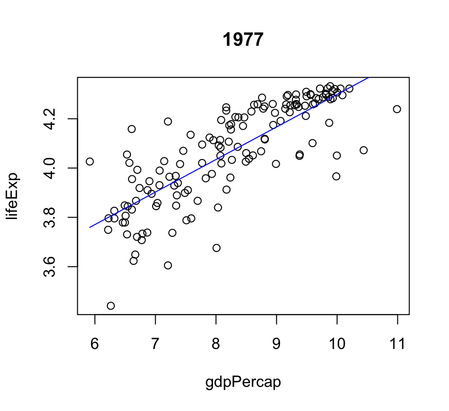

```r
viz_lm(gapminder, "lifeExp", "gdpPercap", 1977)
```

## Loop it!

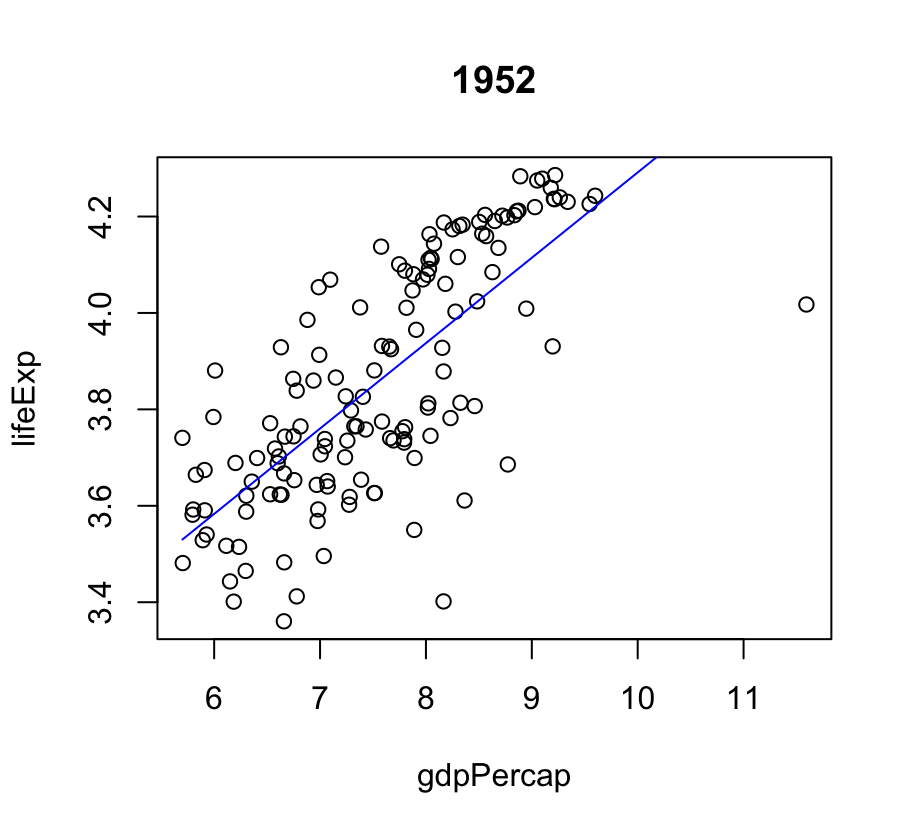

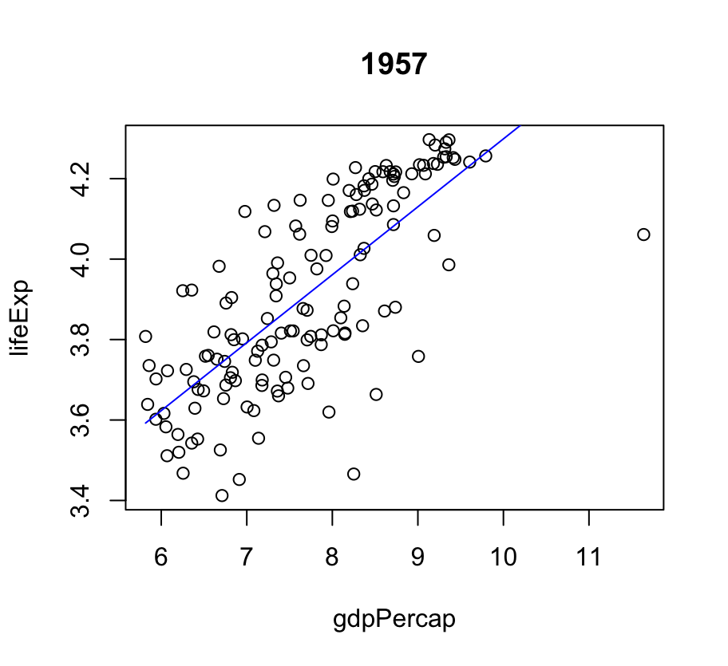

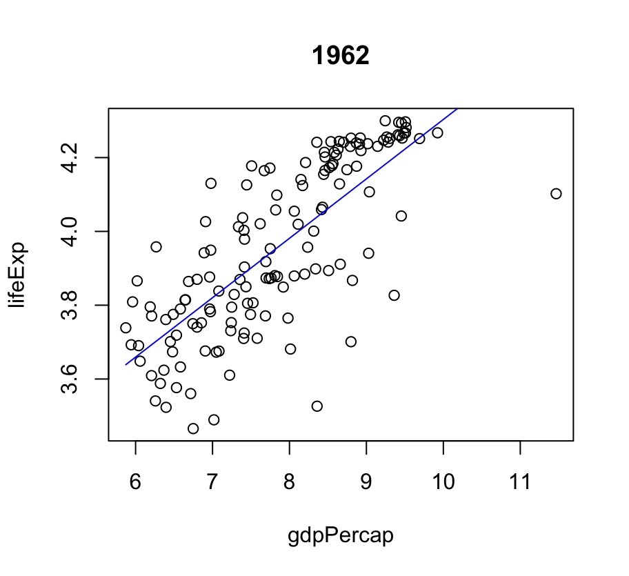

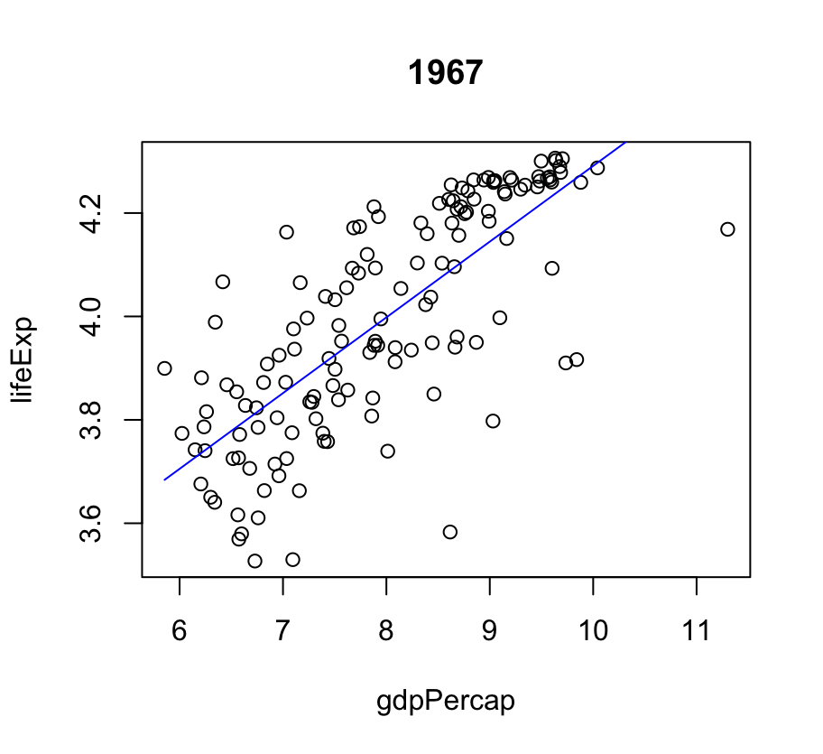

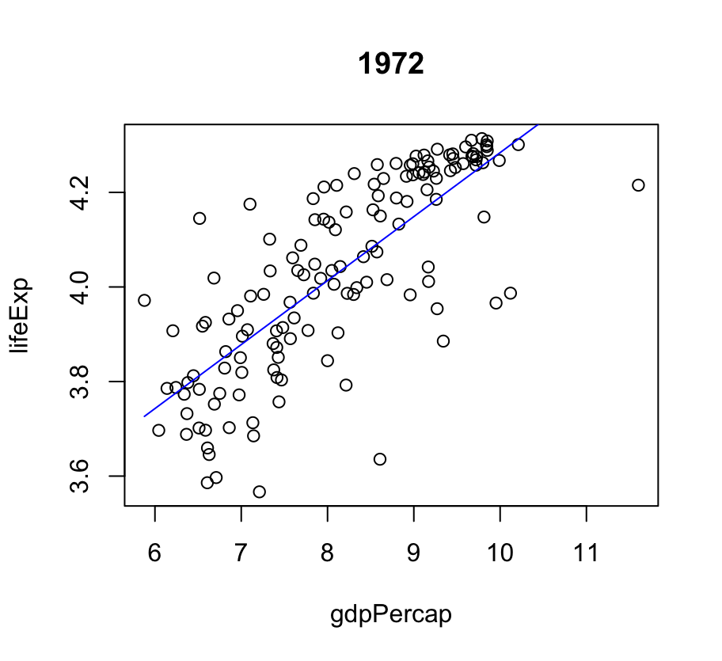

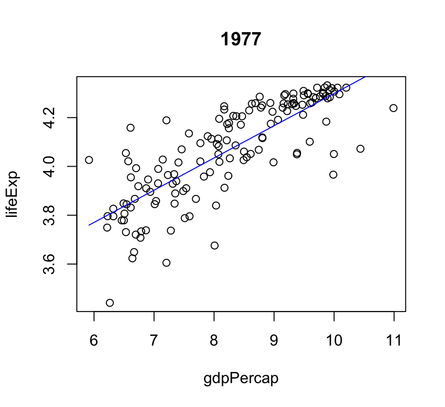

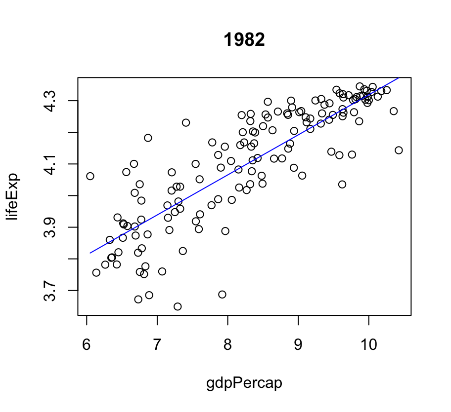

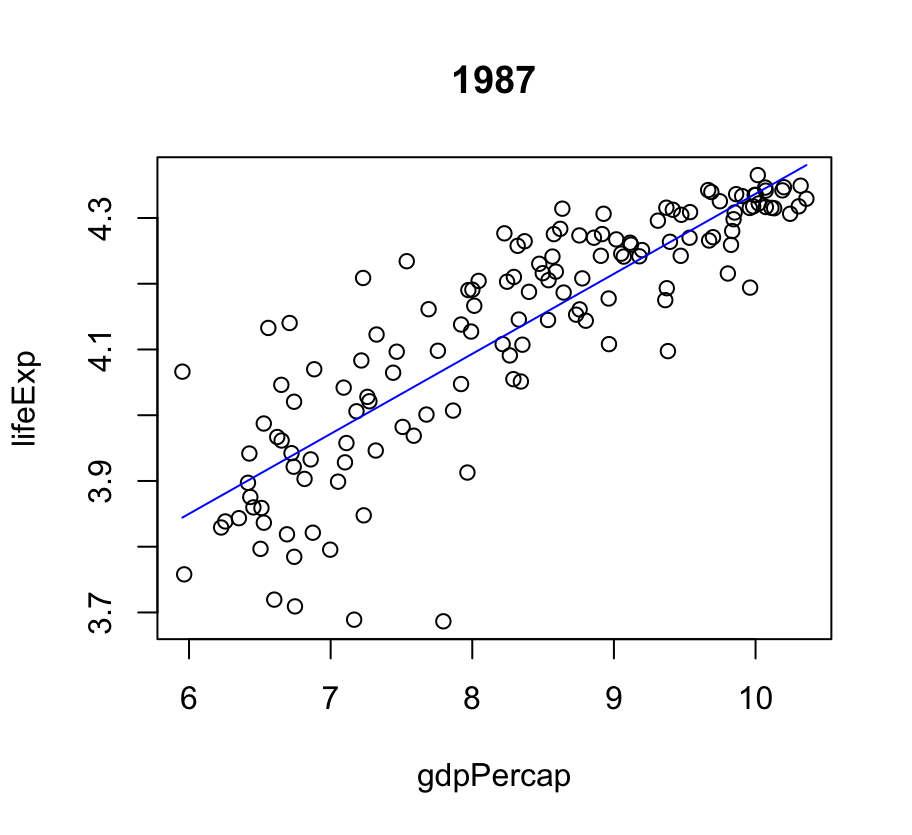

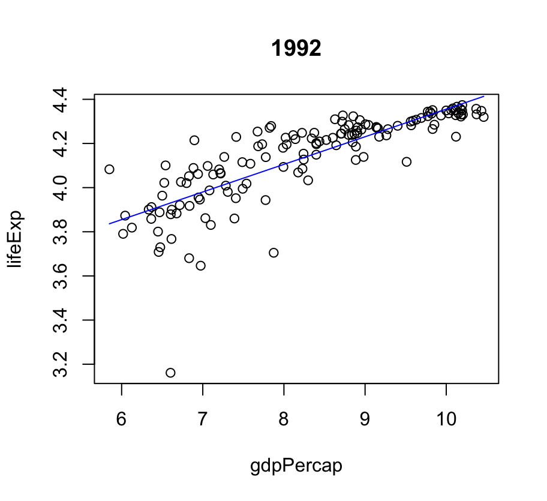

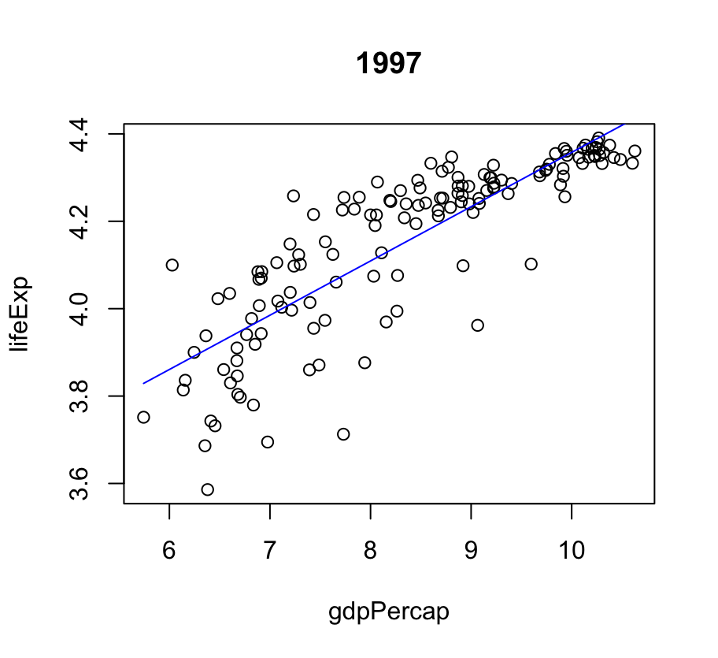

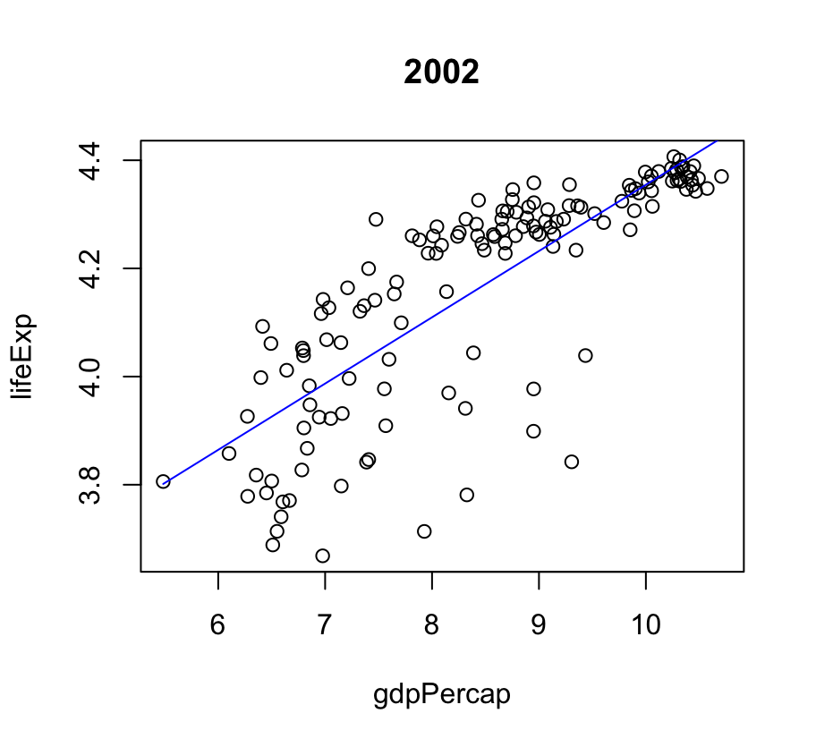

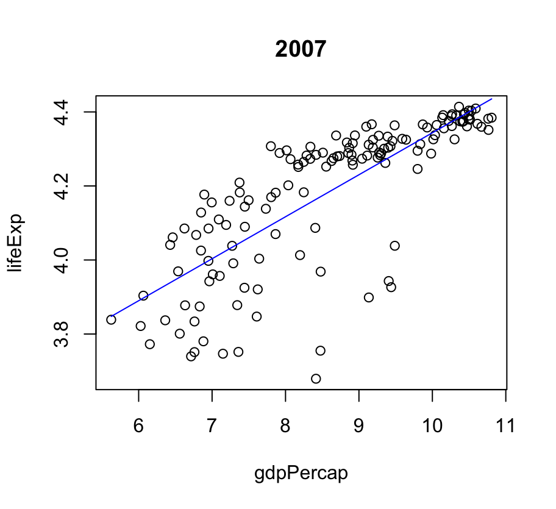

```r
for (i in years) {
  viz_lm(gapminder, "lifeExp", "gdpPercap", i)
}
```

# Reporting analysis with Rmarkdown and GitHub

## Rmarkdown & GitHub

- Rmarkdown creates dynamic reports in HTML, PDF, and Word
- Combine text (using the markdown language) and R code
- Rmarkdown runs R code, compiles, and produces a report in chosen format
- This presentation was created using Rmarkdown!

## R4 Exercise

1. Open the `rmd_exercise_template.Rmd`
2. Save as: `R4RExercise_LastnameFirstname.Rmd`.
3. Read in the gapminder data set
4. As you answer questions, be sure to annotate your work with as much detail as possible!